# KhaledHelmy: Traffic Data Analysis

```r
library(dplyr)
library(lubridate)
```

```r
library(stringr)
library(corrplot)
library(caret)
library(ggplot2)
```

## Reading Data

```r
data = read.csv("../all-semi-unique.csv")
dim(data)
```

```
## [1] 429982     34
```

```r
names(data)
```

```
##  [1] "crawl_date"      "ad.aid"          "ad.bgcl"
##  [4] "ad.bgcls"        "ad.fncl"         "ad.fncls"
##  [7] "ad.lid"          "ad.logo"         "ad.logo2x"
## [10] "ad.logoAndroidS" "ad.logoAndroidH" "ad.cm"
## [13] "ad.url"          "ad.g"            "rd.nm"
## [16] "rd.ri"           "rd.stid"         "rd.hr"
## [19] "rd.mn"           "rd.new"          "rd.img"
## [22] "rd.cl"           "rd.strq"         "rd.cmrq"
## [25] "rd.rp.nm"        "rd.rp.fullnm"    "rd.rp.hr"
## [28] "rd.rp.mn"        "rd.rp.stid"      "rd.rp.cm"
## [31] "rd.rp.cmid"      "rd.rp.rpImg"     "rd.rp.img"
## [34] "rd.rp.type"
```

```r
str(data)
```

```
## 'data.frame':    429982 obs. of  34 variables:
##  $ crawl_date     : Factor w/ 28331 levels "Fri Feb 12 00:00:14 UTC 2016",..: 1869 1869 1869 1869 8758 8758 8809 8809 8862 8862 ...
##  $ ad.aid         : int  2538 2538 2538 2538 2538 2538 2538 2538 2538 2538 ...
##  $ ad.bgcl        : Factor w/ 1 level "#003768": 1 1 1 1 1 1 1 1 1 1 ...
##  $ ad.bgcls       : Factor w/ 1 level "#0069aa": 1 1 1 1 1 1 1 1 1 1 ...
##  $ ad.fncl        : Factor w/ 1 level "#FFFFFF": 1 1 1 1 1 1 1 1 1 1 ...
##  $ ad.fncls       : Factor w/ 1 level "#FFFFFF": 1 1 1 1 1 1 1 1 1 1 ...
##  $ ad.lid         : int  1001 1001 1001 1001 1001 1001 1001 1001 1001 1001 ...
##  $ ad.logo        : Factor w/ 1 level "http://www.bey2ollak.com/downloads/logos/Pepsi_SA7EL.png": 1 1 1 1 1 1 1 1 1 1 ...
##  $ ad.logo2x      : Factor w/ 1 level "http://www.bey2ollak.com/downloads/logos/Pepsi_SA7EL@2x.png": 1 1 1 1 1 1 1 1 1 1 ...
##  $ ad.logoAndroidS: Factor w/ 1 level "http://www.bey2ollak.com/downloads/logos/Pepsi_SA7EL_ANDROID_S.png": 1 1 1 1 1 1 1 1 1 1 ...
##  $ ad.logoAndroidH: Factor w/ 1 level "http://www.bey2ollak.com/downloads/logos/Pepsi_SA7EL_ANDROID_H.png": 1 1 1 1 1 1 1 1 1 1 ...
##  $ ad.cm          : Factor w/ 1 level "دوس هنا وشوف إعلان بيبسي الجديد مع محمد صلاح #يلا_تقدر": 1 1 1 1 1 1 1 1 1 1 ...
##  $ ad.url         : Factor w/ 1 level "http://youtu.be/aNeqShdgupY": 1 1 1 1 1 1 1 1 1 1 ...
##  $ ad.g           : int  1 1 1 1 1 1 1 1 1 1 ...
```

[output cut: 20 more lines]

```r
summary(data)
```

```
##                         crawl_date         ad.aid        ad.bgcl
##  Sun Feb 14 22:30:08 UTC 2016:   120   Min.   :2538   #003768:429982
##  Sun Feb 14 22:30:10 UTC 2016:   120   1st Qu.:2538
##  Sun Feb 14 22:30:11 UTC 2016:   120   Median :2538
##  Sun Feb 14 22:30:14 UTC 2016:   120   Mean   :2538
##  Sun Feb 14 22:30:15 UTC 2016:   120   3rd Qu.:2538
##  Sun Feb 14 23:00:09 UTC 2016:   120   Max.   :2538
##  (Other)                     :429262
##     ad.bgcls         ad.fncl          ad.fncls          ad.lid
##  #0069aa:429982   #FFFFFF:429982   #FFFFFF:429982   Min.   :1001
##                                                     1st Qu.:1001
##                                                     Median :1001
##                                                     Mean   :1001
##                                                     3rd Qu.:1001
##                                                     Max.   :1001
##
##                                                      ad.logo
##  http://www.bey2ollak.com/downloads/logos/Pepsi_SA7EL.png:429982
##
##
##
##
##
##
##                                                        ad.logo2x
##  http://www.bey2ollak.com/downloads/logos/Pepsi_SA7EL@2x.png:429982
##
##
##
##
##
##
##                                                            ad.logoAndroidS
##  http://www.bey2ollak.com/downloads/logos/Pepsi_SA7EL_ANDROID_S.png:429982
##
##
##
##
##
##
```

[output cut: 57 more lines]

```
##  Min.   : 0.0   Min.   : 1.00   lazeez       : 76106   Min.   :9271509
##  1st Qu.:14.0   1st Qu.: 2.00   mashy        : 21710   1st Qu.:9338581
##  Median :29.0   Median : 3.00   7alawa       : 16996   Median :9376096
##  Mean   :29.2   Mean   : 4.71   za7ma        : 14183   Mean   :9376278
##  3rd Qu.:44.0   3rd Qu.:10.00   Eih el nezam?: 14127   3rd Qu.:9413977
##  Max.   :59.0   Max.   :10.00   mafeesh amal :  7904   Max.   :9452302
##                 NA's   :13965   (Other)      :278956
##   rd.rp.rpImg       rd.rp.img        rd.rp.type
##  Min.   : 21970   Min.   :    50   Min.   :0
##  1st Qu.:458600   1st Qu.: 62923   1st Qu.:0
##  Median :461455   Median : 62923   Median :0
##  Mean   :461014   Mean   :146707   Mean   :0
##  3rd Qu.:464205   3rd Qu.:233366   3rd Qu.:0
##  Max.   :467309   Max.   :467247   Max.   :0
##  NA's   :411585   NA's   :152557
```

Having a look on the first few rows of the data.

```r
head(data)
```

```
##                     crawl_date ad.aid ad.bgcl ad.bgcls ad.fncl ad.fncls
## 1 Fri Feb  5 17:23:57 UTC 2016   2538 #003768  #0069aa #FFFFFF  #FFFFFF
## 2 Fri Feb  5 17:23:57 UTC 2016   2538 #003768  #0069aa #FFFFFF  #FFFFFF
## 3 Fri Feb  5 17:23:57 UTC 2016   2538 #003768  #0069aa #FFFFFF  #FFFFFF
## 4 Fri Feb  5 17:23:57 UTC 2016   2538 #003768  #0069aa #FFFFFF  #FFFFFF
## 5 Sat Feb  6 08:01:00 UTC 2016   2538 #003768  #0069aa #FFFFFF  #FFFFFF
## 6 Sat Feb  6 08:01:00 UTC 2016   2538 #003768  #0069aa #FFFFFF  #FFFFFF
##   ad.lid                                                  ad.logo
## 1   1001 http://www.bey2ollak.com/downloads/logos/Pepsi_SA7EL.png
## 2   1001 http://www.bey2ollak.com/downloads/logos/Pepsi_SA7EL.png
## 3   1001 http://www.bey2ollak.com/downloads/logos/Pepsi_SA7EL.png
## 4   1001 http://www.bey2ollak.com/downloads/logos/Pepsi_SA7EL.png
## 5   1001 http://www.bey2ollak.com/downloads/logos/Pepsi_SA7EL.png
## 6   1001 http://www.bey2ollak.com/downloads/logos/Pepsi_SA7EL.png
##                                                     ad.logo2x
```

[output cut: 62 more lines]

## Cleaning Data

### Processing Columns

Removing advertisements columns.

```r
data <- data %>% select(-starts_with("ad."))
ncol(data)
```

```
## [1] 21
```

```r
names(data)
```

```
##  [1] "crawl_date"   "rd.nm"        "rd.ri"        "rd.stid"
##  [5] "rd.hr"        "rd.mn"        "rd.new"       "rd.img"
##  [9] "rd.cl"        "rd.strq"      "rd.cmrq"      "rd.rp.nm"
## [13] "rd.rp.fullnm" "rd.rp.hr"     "rd.rp.mn"     "rd.rp.stid"
## [17] "rd.rp.cm"     "rd.rp.cmid"   "rd.rp.rpImg"  "rd.rp.img"
## [21] "rd.rp.type"
```

Removing road images, colors and rode report images.

```r
data <- subset(data, select = -c(rd.img, rd.cl, rd.rp.rpImg, rd.rp.img))
ncol(data)
```

```
## [1] 17
```

```r
names(data)
```

```
##  [1] "crawl_date"   "rd.nm"        "rd.ri"        "rd.stid"
##  [5] "rd.hr"        "rd.mn"        "rd.new"       "rd.strq"
##  [9] "rd.cmrq"      "rd.rp.nm"     "rd.rp.fullnm" "rd.rp.hr"
## [13] "rd.rp.mn"     "rd.rp.stid"   "rd.rp.cm"     "rd.rp.cmid"
## [17] "rd.rp.type"
```

### Processing Rows

Checking number of duplicate rows.

```r
nrow(data) - nrow(unique(data))
```

```
## [1] 0
```

Removing rows with same comment id.

```r
data <- data %>% distinct(rd.rp.cmid)
nrow(data)
```

```
## [1] 148367
```

## Feature Engineering

Checking proportion of N/A values.

```r
sum(is.na(data)) / nrow(data) / ncol(data)
```

```
## [1] 0.01321524
```

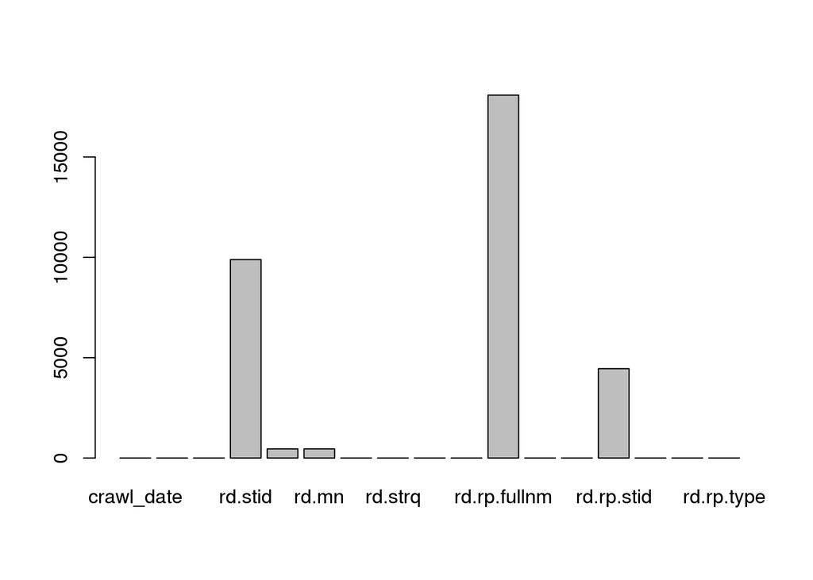

```r
barplot(sapply(data, function(col) sum(is.na(col))))
```

### Feature Removal

Checking columns with constant features and printing their names.

```r
col_ct = sapply(data, function(x) length(unique(x)))
length(col_ct[col_ct == 1])
```

```
## [1] 1
```

```r
names(col_ct[col_ct == 1])
```

```
## [1] "rd.rp.type"
```

Removing constant-feature columns.

```r
data = data[, !names(data) %in% names(col_ct[col_ct == 1])]
ncol(data)
```

```
## [1] 16
```

```r
names(data)
```

```
##  [1] "crawl_date"   "rd.nm"        "rd.ri"        "rd.stid"
##  [5] "rd.hr"        "rd.mn"        "rd.new"       "rd.strq"
##  [9] "rd.cmrq"      "rd.rp.nm"     "rd.rp.fullnm" "rd.rp.hr"
## [13] "rd.rp.mn"     "rd.rp.stid"   "rd.rp.cm"     "rd.rp.cmid"
```

Finding featues with high correlation values.

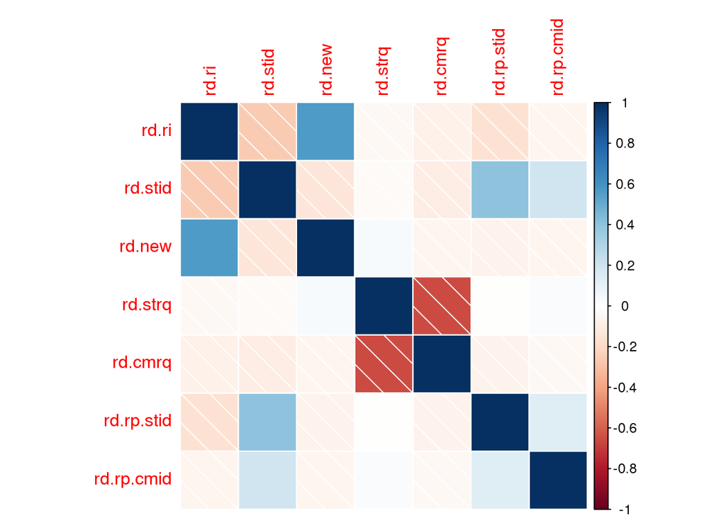

```r
cor_feats = c("rd.ri", "rd.stid", "rd.new", "rd.strq", "rd.cmrq", "rd.rp.stid", "rd.rp.cmid")
cor_mat = cor(data[, cor_feats], use = "complete")
corrplot(method = "shade", cor_mat)
```

```r
cor_threshold = 0.6
high_cor <- findCorrelation(cor_mat, cutoff = cor_threshold)
cor_feats[high_cor]
```

```
## [1] "rd.cmrq"
```

### Feature Creation

Formatting `crawl_date` into a proper `datetime` format and changing the timezone from `UTC` to `Egypt`.

```r
data$formatted_crawl_date <- as.POSIXct(data$crawl_date, format = "%a %b %d %T UTC %Y", tz = "UTC")
data$formatted_crawl_date <- as.POSIXct(c(data$formatted_crawl_date), tz = "Egypt")
head(data$crawl_date)
```

```
## [1] Fri Feb  5 17:23:57 UTC 2016 Fri Feb  5 17:23:57 UTC 2016
## [3] Fri Feb  5 17:23:57 UTC 2016 Fri Feb  5 17:23:57 UTC 2016
## [5] Sat Feb  6 08:01:00 UTC 2016 Sat Feb  6 08:01:00 UTC 2016
## 28331 Levels: Fri Feb 12 00:00:14 UTC 2016 ... Wed Feb 17 23:31:03 UTC 2016
```

```r
head(data$formatted_crawl_date)
```

```
## [1] "2016-02-05 19:23:57 EET" "2016-02-05 19:23:57 EET"
## [3] "2016-02-05 19:23:57 EET" "2016-02-05 19:23:57 EET"
## [5] "2016-02-06 10:01:00 EET" "2016-02-06 10:01:00 EET"
```

```r
str(data$formatted_crawl_date)
```

```
##  POSIXct[1:148367], format: "2016-02-05 19:23:57" "2016-02-05 19:23:57" ...
```

Adding `report_date` to the data frame.

```r
data$report_date <- data$formatted_crawl_date - hours(data$rd.rp.hr) - minutes(data$rd.rp.mn)
head(data$report_date)
```

```
## [1] "2016-02-05 00:45:57 EET" "2016-02-04 22:57:57 EET"
## [3] "2016-02-04 21:17:57 EET" "2016-02-04 19:36:57 EET"
## [5] "2016-02-05 10:29:00 EET" "2016-02-05 05:05:00 EET"
```

Adding `road_date` to the data frame.

```r
data$road_date <- data$formatted_crawl_date - hours(data$rd.hr) - minutes(data$rd.mn)
head(data$road_date)
```

```
## [1] "2016-02-05 18:11:57 EET" "2016-02-05 18:11:57 EET"
## [3] "2016-02-05 18:11:57 EET" "2016-02-05 18:11:57 EET"
## [5] "2016-02-06 00:56:00 EET" "2016-02-06 00:56:00 EET"
```

Finding road delimiters.

```r
nrow(data) - length(which(grepl(";", data$rd.nm))) - length(which(grepl("-", data$rd.nm))) - length(which(grepl("/", data$rd.nm)))
```

```
## [1] 3648
```

```r
missed_delimiters <- which(!grepl(";", data$rd.nm) & !grepl("-", data$rd.nm) & !grepl("/", data$rd.nm))

unique(data[missed_delimiters,]$rd.nm)
```

```
##  [1] Ba7ary                            Ma3ady
##  [3] Sidi Gaber                        Sidi Bishr
##  [5] Zamalek                           Other Roads
##  [7] Ma7atet ElRaml                    Elibrahimeya
##  [9] Waslet Kobry 6 October To 15 Mayo Midan ElTa7rir
## [11] Tagamo3                           Masr ElGedeeda
## [13] Mohandesin                        Gleem
## [15] Roushdy                           West ElBalad
## [17] توتال (برج العرب)                 Madinet Nasr
## 301 Levels: 14 Mayo Road;Kobry 14 Mayo To Mad5al Smou7a ...
```

Splitting road names into areas and roads.

```r
data <- data %>% mutate(
  area = ifelse(grepl(";", rd.nm),
                str_split_fixed(rd.nm, ";", 2)[, 1],
                ifelse(grepl("-", rd.nm),
                       str_split_fixed(rd.nm, "-", 2)[, 1],
                       ifelse(grepl("/", rd.nm),
                              str_split_fixed(rd.nm, "/", 2)[, 1],
                              rd.nm)))

  ,

  road = ifelse(grepl(";", rd.nm),
                str_split_fixed(rd.nm, ";", 2)[, 2],
                ifelse(grepl("-", rd.nm),
                       str_split_fixed(rd.nm, "-", 2)[, 2],
                       ifelse(grepl("/", rd.nm),
                              str_split_fixed(rd.nm, "/", 2)[, 2],
                              NA)))
)
```

Getting road directions.

```r
data <- data %>% mutate(
  road_from = ifelse(is.na(road), NA, str_split_fixed(road, " To ", 2)[, 1])

  ,

  road_to = ifelse(is.na(road), NA, str_split_fixed(road, " To ", 2)[, 2])
)
```

Adding `city` to data frame.

```r
cairo_roads <- c("Line 1", "Line 2", "Line 3", "Autostrad", "Ba7r A3zam", "Da2ery", "El Wasla", "Mansoureya", "Faissal St.", "Gesr ElSuez", "Haram St.", "Ismailia Rd.", "Ismailia Road", "Me7war Sa3d ElShazly", "Kobry 15 Mayo", "Kobry 3abbas", "Kobry 6 October", "Ta7t K.October(Lotfy ElSayed)", "Ta7t K.October(Mahmasha)", "Waslet Kobry 6 October To 15 Mayo", "Kobry Kasr ElNile", "Kobry ElGam3a", "Kornich ElNile", "AlKasr Al3eny St.", "Kornich Agouza", "Nasr st", "Zahraa st", "Ma3ady", "Mostafa ElNa7as", "Zaker 7esein", "3abbas El3akkad", "Makram 3ebeid", "Tayaran St.", "Madinet Nasr", "Khalifa ElMa2moun St.", "Marghani St.", "Nozha St", "Thawra St.", "Masr ElGedeeda", "Me7war", "Me7war Ahmed 3orabi", "Me7war Saft ElLaban", "Me7war ElKhalafawy", "Me7war ElShaheed", "Batal Ahmed St.", "Gam3et ElDewal St", "Mohandesin", "Sudan St.", "Tahrir St.", "Morad St.", "Nafa2 ElAzhar", "NA Road", "90 St.", "Emtedad Ramses", "Lotfy ElSayed", "Ramses St.", "ElGala2", "Waslet Pyramids Heights", "Sa7rawy", "Sala7 Salem", "Suez Rd.", "Fayoum Rd.", "Wahat Road", "West ElBalad", "Midan ElTa7rir", "Zamalek", "Zera3y Road", "Other Roads", "Wadi ElNatron", "Sharm Rd", "Nekhel Rd.", "Saint Catherine Rd.", "Sokhna/Gharda2ah Rd.", "Gharda2ah/Sokhna Rd.", "ElBa7r", "Abukir", "Tram", "Fouad St.-Dawran BabShar2 To Salah Salem", "Sala7 Salem St.-Qesm El3atareen To Mansheya", "Stadium St.-Dawaran Shar2 To Ma7atet Masr", "3orabi Sq. St.-Midan ElMansheya To ElGondy ElMaghoul", "3orabi Sq. St.-ElGondy ElMaghoul To Midan ElMansheya", "EL Batalsa st.-Alexandria Stadium To Sultan Hussin St.", "Champollion st.-Koleyet ElTeb To ElBa7r", "Soutr st.-ElBa7r To ElShalalat", "Masged ElKa2ed Ibrahim St.-Champollion st. To Masged ElKa2ed Ibrahim", "Masged ElKa2ed Ibrahim St.-Masged ElKa2ed Ibrahim To Champollion st.", "Kobry ElGam3a St.-Tram To AbuKir St.", "Kobry ElGam3a St.-AbuKir St. To Tram", "Port Said-Shatby To Sidi Gaber", "Elibrahimeya", "Kobery Elibrahimeya-Fawzy Moaz St. To AbuKir St.", "Kobry Elibrahimeya-AbuKir St. To Fawzy Moaz St.", "Zaki Ragab St-Kobry ElIbrahimeya To Dawaran 3ezbet Sa3d", "Zaki Ragab St-Dawaran 3ezbet Sa3d To Kobry ElIbrahimeya", "Fawzy Mo3az St.-Smou7a Sq. To Elibrahimeya Sq.", "Fawzy Mo3az St.-Elibrahimeya Sq. To Smou7a Sq.", "Albert ElAwal St-Kobry Cleopatra To Game3 Ali Ebn Abi Taleb", "Albert ElAwal St-Game3 Ali Ebn Abi Taleb To Dawaran 3ezbet Sa3d", "Albert ElAwal St-3ezbet Sa3d To Game3 Ali Ebn Abi Taleb", "Albert ElAwal St-Game3 Ali Ebn Abi Taleb To Kobry Cleopatra", "Edmon Fremon St-Kobry ElTagneed To Game3 Aly Ebn Abi Taleb", "Victor Emmanuel St-Dawaran Smou7a To Nafa2 ElReyada", "Victor Emmanuel St-Nafa2 ElReyada To Dawaran Smou7a", "Ibrahim Sherif St-Mostafa Kamel To Nafa2 ElReyada", "Ibrahim Sherif St-Nafa2 ElReyada To Mostafa Kamel", "Tut Ankh Amun St-Kobry Cleopatra To Kobry ElIbrahimeya", "Ismael Serry St-ElTa2meen ElSe7y To Dawaran 3ezbet Sa3d", "Ismael Serry St-Dawaran 3ezbet Sa3d To ElTa2meen ElSe7y", "Zahran St-Midan Victor Emmanuel To Koleyet ElTamreed", "Mostafa Kamel St (Smou7a)-Kobry Cleopatra To Nady Smou7a", "14 Mayo Road-Madkhal Smou7a To Kobry 14 Mayo", "14 Mayo Road-Kobry 14 Mayo To Midan Victor Emmanuel", "14 Mayo Road-Midan Victor Emmanuel To Kobry 14 Mayo", "14 Mayo Road-Kobry 14 Mayo To Mad5al Smou7a", "Nozha Road-Dawaran 3ezbet Sa3d To Kobry ElTagneed", "Nozha Road-Kobry ElTagneed To Dawaran 3ezbet Sa3d", "Kanat ElMa7moudeya Road-El3awayed To 7agar AlNwateya", "Kanat ElMa7moudeya Road-7agar AlNwateya To Kobry ElTagneed", "Kanat ElMa7moudeya Road-Kobry ElTagneed To Mo7aram Beik", "Kanat ElMa7moudeya Road-Mo7aram Beik To Kobry ElTagneed", "Kanat ElMa7moudeya Road-Kobry ElTagneed To 7agar ElNwateya", "Kanat ElMa7moudeya Road-7agar AlNawateya To El3awayed", "Gamal Abdel Nasser", "Safeya Zaghloul St.-Ma7atet ElRaml To Ma7atet Masr", "Sidi Bishr", "Sultan Hussein St.-West ElBalad To Dawaran Shar2y", "Sultan Hussein St.-Dawaran Shar2y To West ElBalad", "Gleem", "Mostafa Kamel St.-Bokla To Medan Elsa3a", "Ma7atet ElRaml", "Sidi Gaber", "Malak Hefny St.-Victoria To Sidi Bishr Seka 7adid", "Masged Sidi Beshr St-Sidi Beshr El7ay To ElBa7r", "Masged Sidi Beshr St-ElBa7r To Sidi Beshr El7ay", "Mohamed Nageeb St-Gamal Abdel Naser To Awel El3esawy", "Mohamed Nageeb St-Awel El3esawy To Gamal Abdel Naser", "El3esawy St-Mohamed Nageeb To ElEskandar Ibrahim", "Khaled Ebn ElWaleed St-Tram Sidi Beshr To Ramada Hotel", "Khaled Ebn ElWaleed St-Ramada Hotel To Miamy", "ElEskandar Ibrahim St-Gamal Abdel Naser To ElBa7r", "ElEskandar Ibrahim St-ElBa7r To Gamal Abdel Naser", "45 St-Mostafa Kamel St To Kobry 45", "45 St-Kobry 45 To ElBa7r", "45 St-ElBa7r To Kobry 45", "45 St-Kobry 45 To Mostafa Kamel St", "Nabawy ElMohandes St-Kobry ElMandara To Mostafa Kamel St", "Nabawy ElMohandes St-Mosatafa Kamel St To Kobry ElMandara", "ElGhorfa ElTogareya-Ba7ary To Mansheya", "ElGhorfa ElTogareya-Mansheya To Ma7tet ElRaml", "ElGhorfa ElTogareya-Ma7atet ElRaml To Mansheya", "ElGhorfa ElTogareya-Mansheya To Ba7ary", "Ba7ary", "Tari2 Matar ElNozha-Smou7a To Carrefour", "Tari2 Matar ElNozha", "Kanat ElSuez", "Tari2 El 3agamy-Mansheya To 21", "Tari2 El 3agamy-21 To Mansheya", "ElDawly-ElMaw2af ElGedid To Borg El3arab", "El Dawly", "Sa7rawy", "21", "Other Roads", "Sa7rawy-Alex To Cairo", "Sa7rawy-Cairo To Alex", "Syria St.-Roushdy (Abukir St.) To ElBa7r", "ElMo3askar ElRomany St.-ElBa7r To Roushdy (Abukir St.)", "Roushdy")

length(cairo_roads)
```

```
## [1] 168
```

```r
data <- within(data, {
  city <- ifelse(area %in% cairo_roads, "cairo", "alexandria")
})

names(data)
```

```
##  [1] "crawl_date"           "rd.nm"                "rd.ri"
##  [4] "rd.stid"              "rd.hr"                "rd.mn"
##  [7] "rd.new"               "rd.strq"              "rd.cmrq"
## [10] "rd.rp.nm"             "rd.rp.fullnm"         "rd.rp.hr"
## [13] "rd.rp.mn"             "rd.rp.stid"           "rd.rp.cm"
## [16] "rd.rp.cmid"           "formatted_crawl_date" "report_date"
## [19] "road_date"            "area"                 "road"
## [22] "road_from"            "road_to"              "city"
```

```r
head(data)
```

```
##                     crawl_date                                      rd.nm
## 1 Fri Feb  5 17:23:57 UTC 2016 Makram 3ebeid;Autostrad To Mostafa ElNa7as
## 2 Fri Feb  5 17:23:57 UTC 2016 Makram 3ebeid;Autostrad To Mostafa ElNa7as
## 3 Fri Feb  5 17:23:57 UTC 2016 Makram 3ebeid;Autostrad To Mostafa ElNa7as
## 4 Fri Feb  5 17:23:57 UTC 2016 Makram 3ebeid;Autostrad To Mostafa ElNa7as
## 5 Sat Feb  6 08:01:00 UTC 2016 Makram 3ebeid;Autostrad To Mostafa ElNa7as
## 6 Sat Feb  6 08:01:00 UTC 2016 Makram 3ebeid;Autostrad To Mostafa ElNa7as
##   rd.ri rd.stid rd.hr rd.mn rd.new rd.strq rd.cmrq        rd.rp.nm
## 1   678       3     1    12      1       1       0     Tahany_Eyad
## 2   678       3     1    12      1       1       0     7abeba_Sa3d
## 3   678       3     1    12      1       1       0     fa3el kheir
## 4   678       3     1    12      1       1       0 ShahinazSale791
## 5   678      NA     9     5      1       1       0    Gad.Badr1998
## 6   678      NA     9     5      1       1       0      Farghaly13
##     rd.rp.fullnm rd.rp.hr rd.rp.mn rd.rp.stid rd.rp.cm rd.rp.cmid
```

[output cut: 27 more lines]

Adding road speed.

```r
data <- data %>% mutate(
  speed = ifelse(rd.rp.nm == "bey2ollakgps", sapply(str_extract_all(rd.rp.cm, "[0-9]+ km/h|[0-9]+ كم/س"), function(x) paste(x, collapse=',')), NA)
)

data$speed <- gsub(" km/h| كم/س", "", data$speed)

names(data)
```

```
##  [1] "crawl_date"           "rd.nm"                "rd.ri"
##  [4] "rd.stid"              "rd.hr"                "rd.mn"
##  [7] "rd.new"               "rd.strq"              "rd.cmrq"
## [10] "rd.rp.nm"             "rd.rp.fullnm"         "rd.rp.hr"
## [13] "rd.rp.mn"             "rd.rp.stid"           "rd.rp.cm"
## [16] "rd.rp.cmid"           "formatted_crawl_date" "report_date"
## [19] "road_date"            "area"                 "road"
## [22] "road_from"            "road_to"              "city"
## [25] "speed"
```

```r
head(data[which(data$rd.rp.nm == "bey2ollakgps"),])
```

```
##                        crawl_date
## 9    Sat Feb  6 14:31:01 UTC 2016
## 10   Sat Feb  6 14:31:01 UTC 2016
## 82   Sat Feb 13 14:30:59 UTC 2016
## 134  Wed Feb 17 22:31:00 UTC 2016
## 1163 Wed Feb 10 06:00:40 UTC 2016
## 1181 Sat Feb 13 12:00:33 UTC 2016
##                                           rd.nm rd.ri rd.stid rd.hr rd.mn
## 9    Makram 3ebeid;Autostrad To Mostafa ElNa7as   678       2     0    26
## 10   Makram 3ebeid;Autostrad To Mostafa ElNa7as   678       2     0    26
## 82   Makram 3ebeid;Autostrad To Mostafa ElNa7as   678       2     0     4
## 134  Makram 3ebeid;Autostrad To Mostafa ElNa7as   678       2     0    34
## 1163     ElGhorfa ElTogareya;Ba7ary To Mansheya   321      NA    13     8
## 1181     ElGhorfa ElTogareya;Ba7ary To Mansheya   321       2     0    23
##      rd.new rd.strq rd.cmrq     rd.rp.nm rd.rp.fullnm rd.rp.hr rd.rp.mn
```

[output cut: 41 more lines]

## Exploratory Data Analysis

### Identify Metrics and Dimensions

**Dimensions**:

- `crawl_date`: The crawl date and time for a report. It was used to get `formatted_crawl_date`.
- `rd.nm`: The road name. It was used to get the `area` name, `road_from` and `road_to` directions.
- `rd.ri`:

```r
length(unique(data$rd.nm))
```

```
## [1] 301
```

```r
ri <- data %>% group_by(rd.nm) %>% summarize(unique_ri = n_distinct(rd.ri))
length(which(ri$unique_ri > 1))
```

```
## [1] 2
```

```r
ri[which(ri$unique_ri > 1), ]
```

```
## Source: local data frame [2 x 2]
##
##                   rd.nm unique_ri
##                  (fctr)     (int)
## 1           Other Roads         2
## 2 Sa7rawy;Cairo To Alex         2
```

From the above results, `ri` can be considered a road id.

- `rd.stid`: A number corresponding to the status of a road.
- `rd.hr`: The hour value of the last update of a road.
- `rd.mn`: The minute value of the last update of a road.
- `rd.new`:

```r
length(unique(data$rd.new))
```

```
## [1] 2
```

```r
unique(data$rd.new)
```

```
## [1] 1 0
```

```r
length(which(data$rd.new == 0))
```

```
## [1] 137951
```

```r
length(which(data$rd.new == 1))
```

```
## [1] 10416
```

It might be to indicate the state of new reports for a given road.

- `rd.strq` and `rd.cmrq`: From the correlation plot, it is evident that there is a strong (negative) correlation between `rd.strq` and `rd.cmrq`. Further inspecting the relation between the 2 columns:

```r
length(unique(data$rd.strq))
```

```
## [1] 2
```

```r
cmrq <- data %>% group_by(rd.strq) %>% summarize(unique_cmrq = n_distinct(rd.cmrq), mean_cmrq = mean(rd.cmrq))
cmrq[1:2, ]
```

```
## Source: local data frame [2 x 3]
##
##   rd.strq unique_cmrq  mean_cmrq
##     (int)       (int)      (dbl)
## 1       0           1 1.00000000
## 2       1           2 0.02222254
```

They might indicate the a certain state for status requests and comment requests.

- `rd.rp.nm`: The user name of a report.
- `rd.rp.fullnm`: The user full name of a report.
- `rd.rp.hr`: The hour value passed since the publish of the report.
- `rd.rp.mn`: The minute value passed since the public of the report.
- `rd.rp.stid`: The status of a report.
- `rd.rp.cm`: The comment published in a report.
- `rd.rp.cmid`: The id of a comment published in a report.
- `formatted_crawl_date`: The `crawl_date` in local time. It was used to get `report_date`.
- `report_date`: The date and time for a report. It is better than the amount of time passed since the report publish.
- `road_date`: The date and time for a road last update. It is better than the amount of time passed since the road update.
- `area`: The area name of a report.
- `road`: The road name of a report.
- `road_from`: The *from* direction of a road report.
- `road_to`: The *to* direction of a road report. `area`, `road_from` and `road_to` combination is the result of `rd.nm` decomposition. It is better using this decomposition to have a better look on road reports.
- `city`: The road city.
- `speed`: The speed of a road.

*Useful Dimensions*:

- `rd.stid`
- `rd.rp.nm`
- `rd.rp.fullnm`
- `rd.rp.stid`
- `rd.rp.cm`
- `report_date`
- `road_date`
- `area`
- `road_from`
- `road_to`
- `city`
- `speed`

Selecting only these columns for the data

```r
data <- data %>% subset(select = c(rd.stid, rd.rp.nm, rd.rp.fullnm, rd.rp.stid, rd.rp.cm, report_date, road_date, area, road_from, road_to, city, speed, rd.nm))
ncol(data)
```

```
## [1] 13
```

```r
names(data)
```

```
##  [1] "rd.stid"      "rd.rp.nm"     "rd.rp.fullnm" "rd.rp.stid"
##  [5] "rd.rp.cm"     "report_date"  "road_date"    "area"
##  [9] "road_from"    "road_to"      "city"         "speed"
## [13] "rd.nm"
```

```r
head(data)
```

```
##   rd.stid        rd.rp.nm   rd.rp.fullnm rd.rp.stid rd.rp.cm
## 1       3     Tahany_Eyad    Tahany Eyad          2   lazeez
## 2       3     7abeba_Sa3d    7abeba Sa3d          2   lazeez
## 3       3     fa3el kheir           <NA>          2   lazeez
## 4       3 ShahinazSale791 Shahinaz Sale7          2   lazeez
## 5      NA    Gad.Badr1998       Gad Badr          2   lazeez
## 6      NA      Farghaly13     Farghaly13          1   7alawa
##           report_date           road_date          area road_from
## 1 2016-02-05 00:45:57 2016-02-05 18:11:57 Makram 3ebeid Autostrad
## 2 2016-02-04 22:57:57 2016-02-05 18:11:57 Makram 3ebeid Autostrad
## 3 2016-02-04 21:17:57 2016-02-05 18:11:57 Makram 3ebeid Autostrad
## 4 2016-02-04 19:36:57 2016-02-05 18:11:57 Makram 3ebeid Autostrad
## 5 2016-02-05 10:29:00 2016-02-06 00:56:00 Makram 3ebeid Autostrad
## 6 2016-02-05 05:05:00 2016-02-06 00:56:00 Makram 3ebeid Autostrad
##           road_to  city speed                                      rd.nm
## 1 Mostafa ElNa7as cairo  <NA> Makram 3ebeid;Autostrad To Mostafa ElNa7as
## 2 Mostafa ElNa7as cairo  <NA> Makram 3ebeid;Autostrad To Mostafa ElNa7as
## 3 Mostafa ElNa7as cairo  <NA> Makram 3ebeid;Autostrad To Mostafa ElNa7as
## 4 Mostafa ElNa7as cairo  <NA> Makram 3ebeid;Autostrad To Mostafa ElNa7as
## 5 Mostafa ElNa7as cairo  <NA> Makram 3ebeid;Autostrad To Mostafa ElNa7as
## 6 Mostafa ElNa7as cairo  <NA> Makram 3ebeid;Autostrad To Mostafa ElNa7as
```

**Possible Metrics**:

- Users preferences for stating user names and full names.
- The impact of automated GPS reportings.
- User statistics.
- Area and road statistics.
- Area and road statuses throughout the day.
- Area and road reporting times.
- Area and road traffic jams.
- Area and road reporting densities.

### Descriptive Statistics

Finding the number and percentage of users who report without signing in.

```r
length(which(data$rd.rp.nm == "fa3el kheir"))
```

```
## [1] 14690
```

```r
length(which(data$rd.rp.nm == "fa3el kheir")) / length(which(data$rd.rp.nm != "bey2ollakgps"))
```

```
## [1] 0.1630917
```

It shows that 16% of the users report without signing in.

Finding the number and percentage of users who do not state their full names.

```r
sum(is.na(data$rd.rp.fullnm)) - length(which(data$rd.rp.nm == "fa3el kheir"))
```

```
## [1] 3392
```

```r
(sum(is.na(data$rd.rp.fullnm)) - length(which(data$rd.rp.nm == "fa3el kheir"))) / length(which(data$rd.rp.fullnm != "GPS Reporter" & data$rd.rp.nm != "fa3el kheir"))
```

```
## [1] 0.04711766
```

It shows that 5% of signed-in users do not specify their full names.

Finding the impact of automated GPS reportings.

```r
length(which(data$rd.rp.nm == "bey2ollakgps")) / length(data$rd.rp.nm)
```

```
## [1] 0.3929108
```

It shows that around 40% of the reportings are automated reportings.

Finding user statistics.

```r
users <- data %>% group_by(city) %>% summarize(unique_users = length(unique(rd.rp.nm)))
head(users)
```

```
## Source: local data frame [2 x 2]
##
##         city unique_users
##        (chr)        (int)
## 1 alexandria         1482
## 2      cairo        16551
```

Checking nature of values for area status and for road status.

```r
length(unique(data$rd.stid))
```

```
## [1] 11
```

```r
sort(unique(data$rd.stid))
```

```
##  [1]  1  2  3  4  5  6  7  8  9 10
```

```r
length(unique(data$rd.rp.stid))
```

```
## [1] 11
```

```r
sort(unique(data$rd.rp.stid))
```

```
##  [1]  1  2  3  4  5  6  7  8  9 10
```

The status id has 10 different values (besides NA) starting from 1 to 10: * 1: 7alawa * 2: lazeez * 3: mashy * 4: za7ma * 5: mafeesh amal * 6: so2al * 7: khatar (mobile app only) * 8: 7adsa (mobile app only) * 9: 3otl (mobile app only) * 10: ba2olak (mobile app only)

In addition to custom comments by users for certain statuses.

Focusing on the relation between `city`, `area`, `road_from`, `road_to`, `rd.rp.stid` and `speed`.

**Summary Statistics**

```r
#mean_speed = mean(speed),
#median_speed = median(speed),
#mode_speed = smode(speed),
#range_speed = range(speed),
#quartiles_speed = quantile(speed),
#deciles_speed = quantile(speed, probs = seq(0,1,0.1)),
#variance_speed = var(speed),
#sd_speed = sd(speed),
#mad_speed = mad(speed)

stid_central_tendency <- data %>% filter(!is.na(rd.rp.stid)) %>% group_by(rd.nm) %>% summarize(mean_stid = mean(rd.rp.stid)) %>% left_join(data)
head(stid_central_tendency)
```

```
## Source: local data frame [6 x 14]
##
##                                         rd.nm mean_stid rd.stid
##                                        (fctr)     (dbl)   (int)
## 1 14 Mayo Road;Kobry 14 Mayo To Mad5al Smou7a   2.07767      NA
## 2 14 Mayo Road;Kobry 14 Mayo To Mad5al Smou7a   2.07767       2
## 3 14 Mayo Road;Kobry 14 Mayo To Mad5al Smou7a   2.07767       2
## 4 14 Mayo Road;Kobry 14 Mayo To Mad5al Smou7a   2.07767       2
## 5 14 Mayo Road;Kobry 14 Mayo To Mad5al Smou7a   2.07767      NA
## 6 14 Mayo Road;Kobry 14 Mayo To Mad5al Smou7a   2.07767       2
## Variables not shown: rd.rp.nm (fctr), rd.rp.fullnm (fctr), rd.rp.stid
##   (int), rd.rp.cm (fctr), report_date (time), road_date (time), area
##   (chr), road_from (chr), road_to (chr), city (chr), speed (chr)
```

**Data Visualization**

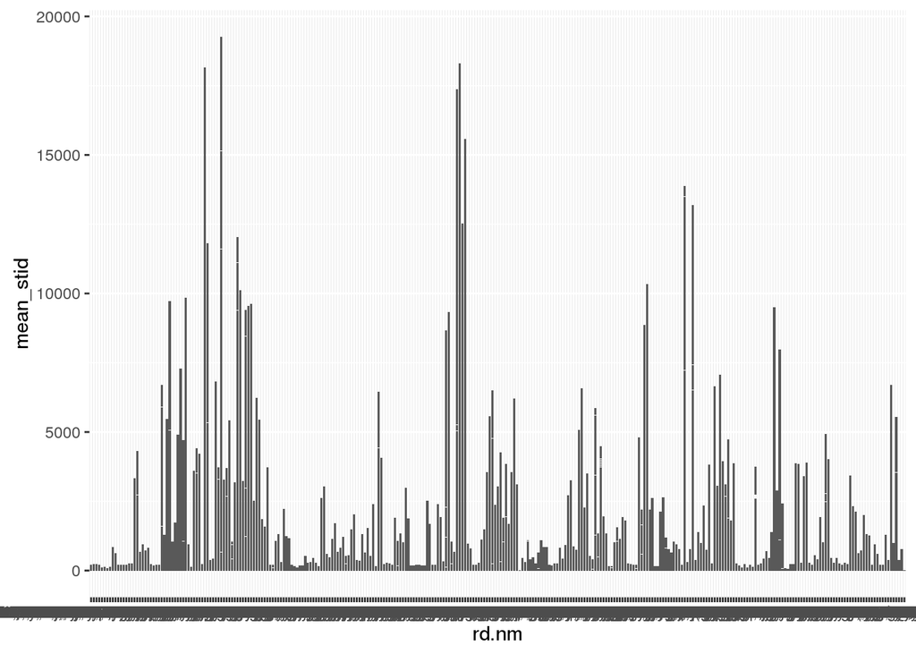

```r
stid_central_tendency %>% ggplot(aes(x = rd.nm, y = mean_stid)) + geom_bar(stat="identity", width = 0.8)
```

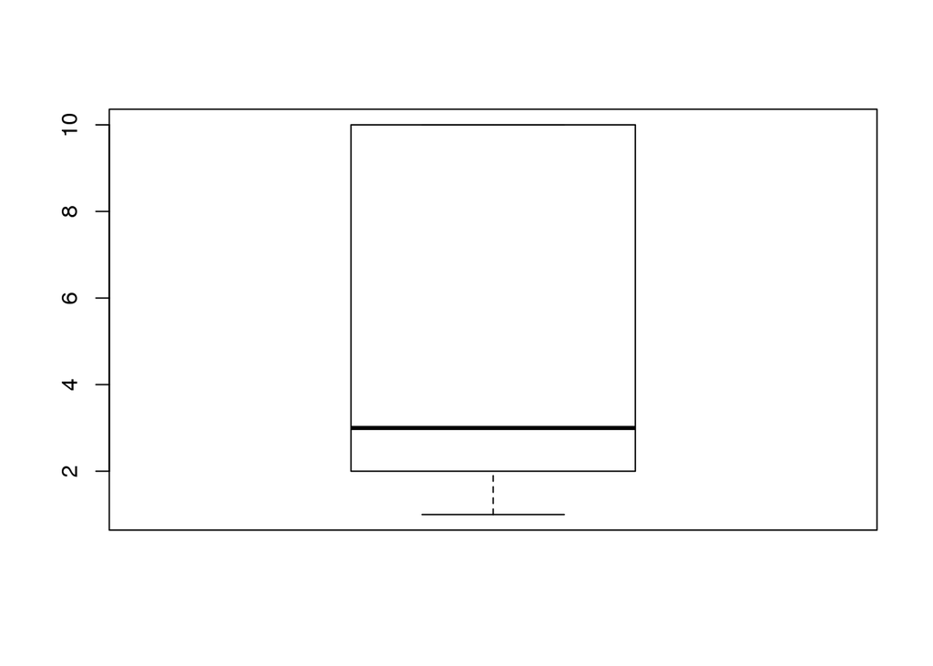

```r
boxplot(stid_central_tendency$rd.rp.stid)
```

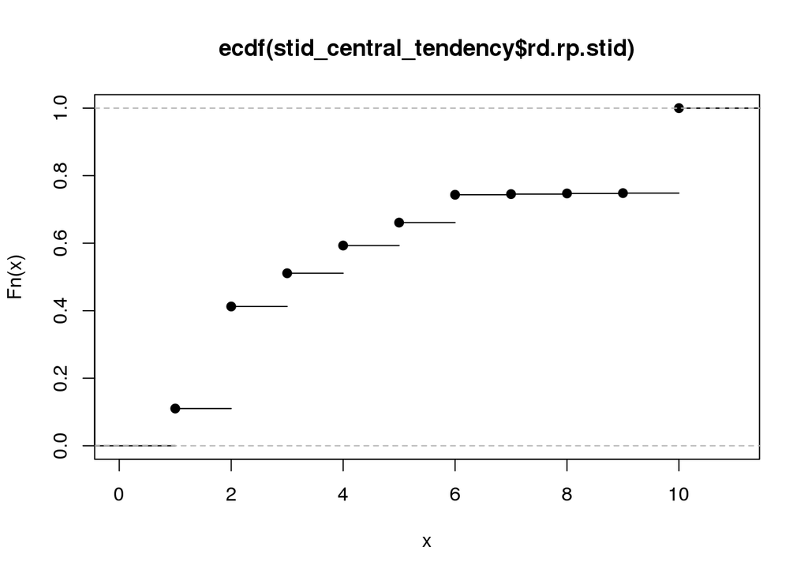

```r
plot(ecdf(stid_central_tendency$rd.rp.stid))
```

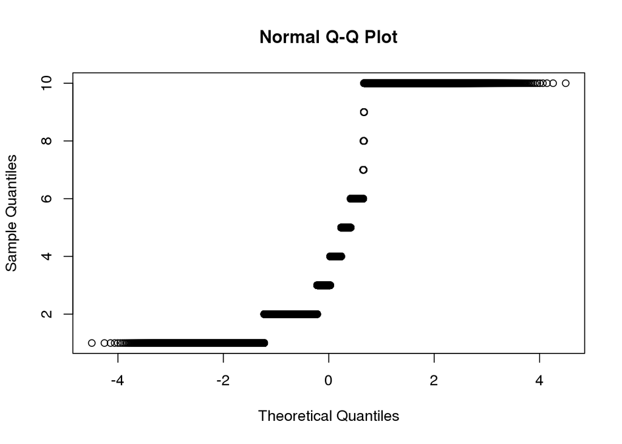

```r
qqnorm(stid_central_tendency$rd.rp.stid)
```

## Inferential Data Analysis

### Parameter Inference (Confidence Intervals)

```r
stid_central_tendency <- stid_central_tendency %>% mutate(error = qt(0.975, df = length(rd.rp.stid)-1)*sd(rd.rp.stid)/sqrt(length(rd.rp.stid)))

stid_central_tendency <- stid_central_tendency %>% mutate(
  left = mean_stid - error,
  right = mean_stid + error
)

head(stid_central_tendency)
```

```
## Source: local data frame [6 x 17]
##
##                                         rd.nm mean_stid rd.stid
##                                        (fctr)     (dbl)   (int)
## 1 14 Mayo Road;Kobry 14 Mayo To Mad5al Smou7a   2.07767      NA
## 2 14 Mayo Road;Kobry 14 Mayo To Mad5al Smou7a   2.07767       2
## 3 14 Mayo Road;Kobry 14 Mayo To Mad5al Smou7a   2.07767       2
## 4 14 Mayo Road;Kobry 14 Mayo To Mad5al Smou7a   2.07767       2
## 5 14 Mayo Road;Kobry 14 Mayo To Mad5al Smou7a   2.07767      NA
## 6 14 Mayo Road;Kobry 14 Mayo To Mad5al Smou7a   2.07767       2
## Variables not shown: rd.rp.nm (fctr), rd.rp.fullnm (fctr), rd.rp.stid
##   (int), rd.rp.cm (fctr), report_date (time), road_date (time), area
##   (chr), road_from (chr), road_to (chr), city (chr), speed (chr), error
##   (dbl), left (dbl), right (dbl)
```